# Bolas_Lab11_LinearRegression

Ellie Bolas, GEO200CN

May 17, 2017

# Linear Regression

### read in data

```r
library (data.table)
datapath <- "C:/Users/ebola/Google Drive/Git/GEO200CN/data"
ROI <- fread (file.path (datapath, "geo200cn_roi.csv"), select=c("tract", "moppl2", "edppl1", "ecppl1", "ecppl2", "hsppl1", "moppl1", "ecplc1", "ecplc3", "hsplc2", "enplc4", "cntyname", "density"))
ROI
```

```
##              tract moppl2 edppl1 ecppl1 ecppl2 hsppl1 moppl1 ecplc1 ecplc3
##   1: 2.970965e-314  43.79  25.29  86.28  72.87  78.47  93.48  320.5  27.85
##   2: 2.970966e-314  35.13  19.42  78.85  53.09  64.33  87.86  393.5  28.67
##   3: 2.970966e-314  36.69  20.92  87.92  83.52  83.17  97.18  395.1  27.73
##   4: 2.970966e-314  42.59  20.12  87.14  67.41  73.95  90.01  393.6  26.41
##   5: 2.970966e-314  35.14  27.59  89.53  71.27  64.08  93.88  389.8  27.24
##  ---
## 837: 3.020229e-314  71.10  37.77  91.62  73.23  63.05  83.84  744.7  31.52
## 838: 3.020229e-314  62.53  38.46  94.07  74.33  79.21  91.08  740.4  31.70
## 839: 3.020229e-314  58.21  32.31  90.88  67.65  58.31  95.53  575.7  14.76
## 840: 3.020229e-314  65.17  19.73  83.13  64.77  62.95  88.69  874.1  17.12
## 841: 3.020229e-314  65.25  26.44  87.39  58.26  65.69  91.95  279.6  28.01
##      hsplc2 enplc4     cntyname density
##   1:   0.20  10.74 Contra Costa      HD
##   2:   0.31  10.28 Contra Costa      HD
##   3:   0.38  10.35 Contra Costa      HD
##   4:   0.29  10.40 Contra Costa      HD
##   5:   0.30  10.57 Contra Costa      HD
##  ---
## 837:   0.27   8.73         Yolo      HD
## 838:   0.24   8.72         Yolo      HD
## 839:   0.19   8.64         Yolo      HD
## 840:   0.25   8.45         Yolo      LD
## 841:   0.26   8.01         Yolo      LD
```

Commute Time: Percentage of workers whose commute time is less than 30 minutes. [moppl2]

### Distribution of moppl2

One of the assumptions of linear regression is that the response variable has an approximately normal distribution where the mean, mode and median are equal, and where the curve is symmetrical around these measurements of central tendency.

#### 1. Using hist() and summary() can we describe the distribution of moppl2 as approximately normal?

```r
summary(ROI$moppl2)
```

```
##    Min. 1st Qu.  Median    Mean 3rd Qu.    Max.    NA's
##   18.68   51.06   61.27   60.94   71.42   97.52      12
```

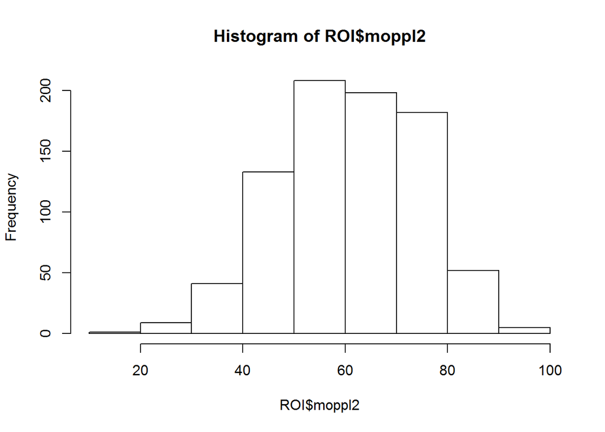

```r
#   Min. 1st Qu.  Median    Mean 3rd Qu.    Max.
#  18.68   51.06   61.27   60.94   71.42   97.52
hist(ROI$moppl2)
```

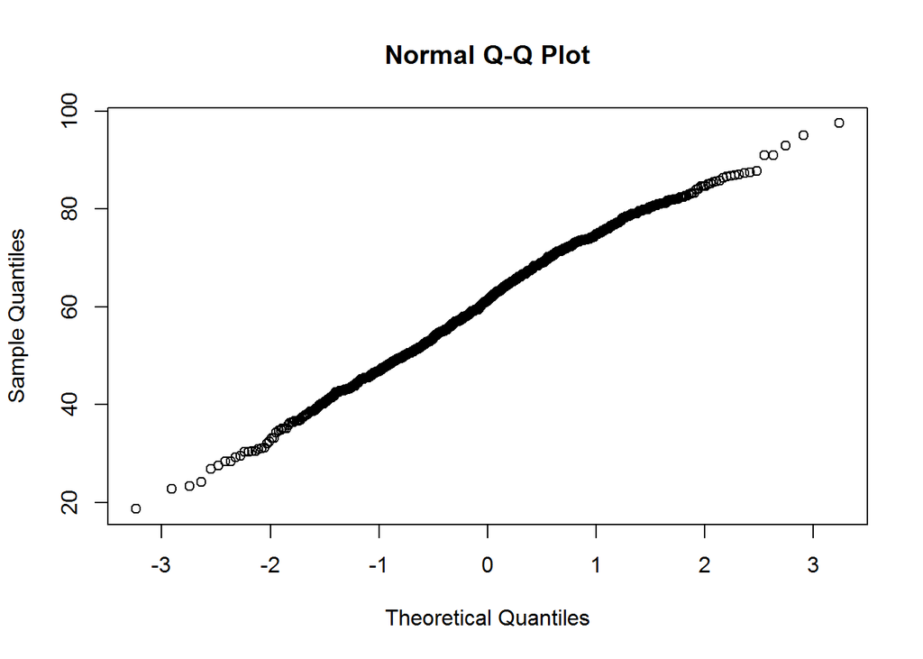

```r
qqnorm(ROI$moppl2)
```

### Multicollinearity

Need to test the explanatory variables for collinearity. Important because if this is the case, it’s difficult to seperate the effects of each predictor. To investigate this, use a correlation matrix.

-Multicollinearity is when there is correlation between 3 or more variables, even though there wasn’t correlation among the pairs of variables. To deal with multicollinearity:compute the Variance Influencing Factor

> > In this case we’ll say that any covariant with a bivariate r of 0.1 or below with moppl2 will be excluded. Where there is multicollinearity measured by a r at or above 0.7 we will exclude the variable with the weakest relationship to moppl2, the lowest r<<

-r is the letter used for the correlation coefficient= Pearson’s r. -bivariate means depending on two variables

The above sentence means: 1. in a bivariate relationship between moppl2 and another variable, exclude the variable with the weakest r, the least correlation. 2. We also want to exclude multicollinearity, so look for any other variables that have a high r >=0.75 that indicate high correlations.

#### Make a correlation matrix exclude census tract, cntyname, density

-are correlation and covariance matrix the same? (Lab instructions say covariance matrix, but this is a correlation matrix. Covariance- the amount of variation in x that can be explained with y. Correlation- how similar the points are moving together. plot one variable as x, one as y, if perfectly correlated, it will be a 45 line.)

```r
#install.packages("corrplot")
library (corrplot)
corrDF <- ROI[,c(-1,-12,-13)]

#cor function computes correlation between variables
#1st arg is the df, use arg means how to deal with NAs while computing, complete.obs means missing values are deleted
M <- cor(corrDF, use="complete.obs")
M
```

```
##             moppl2      edppl1       ecppl1      ecppl2     hsppl1
## moppl2  1.00000000 -0.06716597 -0.109819313 -0.28779343 -0.3445925
## edppl1 -0.06716597  1.00000000  0.623100718  0.73879750  0.4133543
## ecppl1 -0.10981931  0.62310072  1.000000000  0.70041670  0.4463440
## ecppl2 -0.28779343  0.73879750  0.700416702  1.00000000  0.7207588
## hsppl1 -0.34459249  0.41335427  0.446344025  0.72075884  1.0000000
## moppl1 -0.24946647  0.35174289  0.416185092  0.64548958  0.7404704
## ecplc1  0.40388579  0.22473095  0.027230609 -0.02306633 -0.1707922
## ecplc3  0.29317089  0.29544204 -0.009685123 -0.06552557 -0.1969733
## hsplc2 -0.11748472 -0.41053485 -0.190828284 -0.08884253  0.2326508
## enplc4  0.27643738 -0.39608791 -0.406539495 -0.39927453 -0.1728760
##            moppl1      ecplc1       ecplc3      hsplc2      enplc4
## moppl2 -0.2494665  0.40388579  0.293170887 -0.11748472  0.27643738
## edppl1  0.3517429  0.22473095  0.295442035 -0.41053485 -0.39608791
## ecppl1  0.4161851  0.02723061 -0.009685123 -0.19082828 -0.40653950
## ecppl2  0.6454896 -0.02306633 -0.065525569 -0.08884253 -0.39927453
## hsppl1  0.7404704 -0.17079218 -0.196973265  0.23265078 -0.17287601
## moppl1  1.0000000 -0.18034704 -0.237732476  0.19680401 -0.10685357
## ecplc1 -0.1803470  1.00000000  0.747031904 -0.28752117 -0.04342992
## ecplc3 -0.2377325  0.74703190  1.000000000 -0.21009561 -0.10342719
## hsplc2  0.1968040 -0.28752117 -0.210095609  1.00000000  0.35225918
## enplc4 -0.1068536 -0.04342992 -0.103427191  0.35225918  1.00000000
```

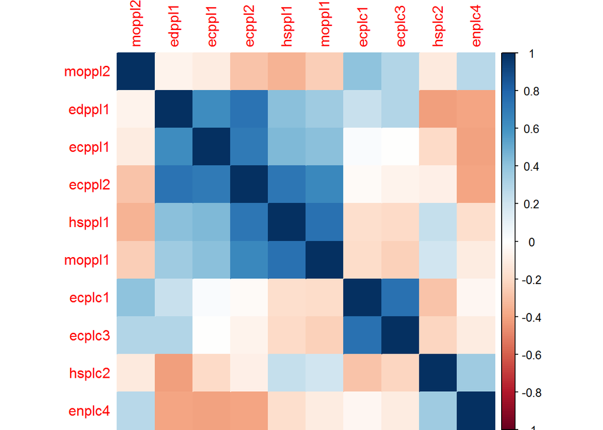

```r
corrplot (M, method="color") #visualization of the matrix with darker colors indicating higher r
```

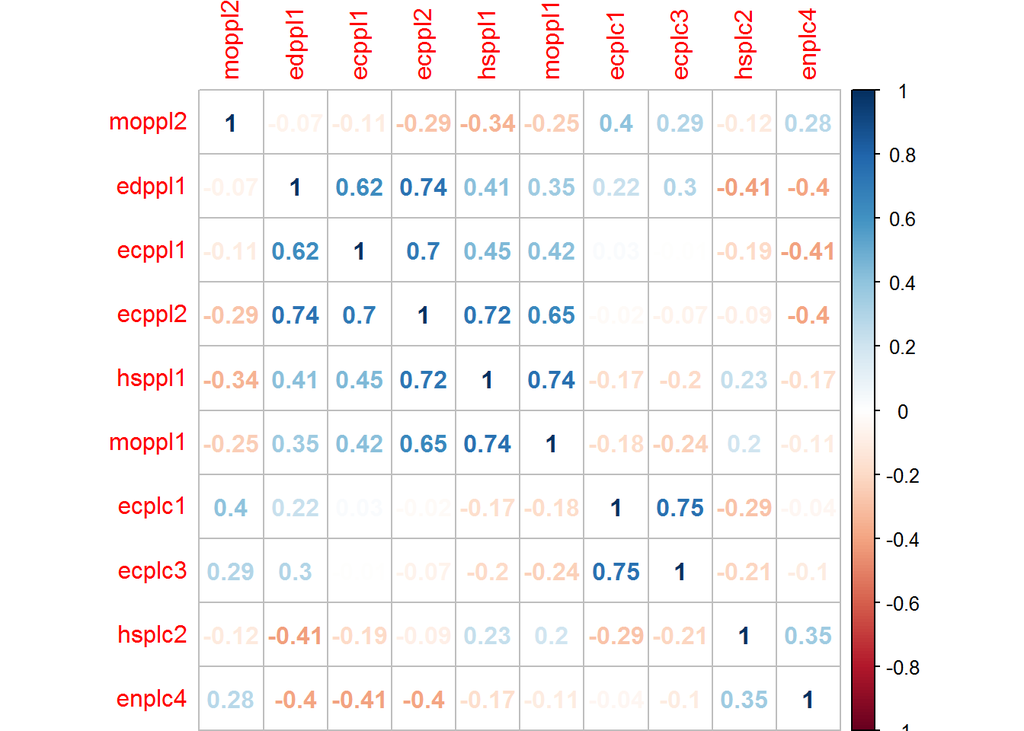

```r
corrplot (M, method="number") #with actual numbers of r
```

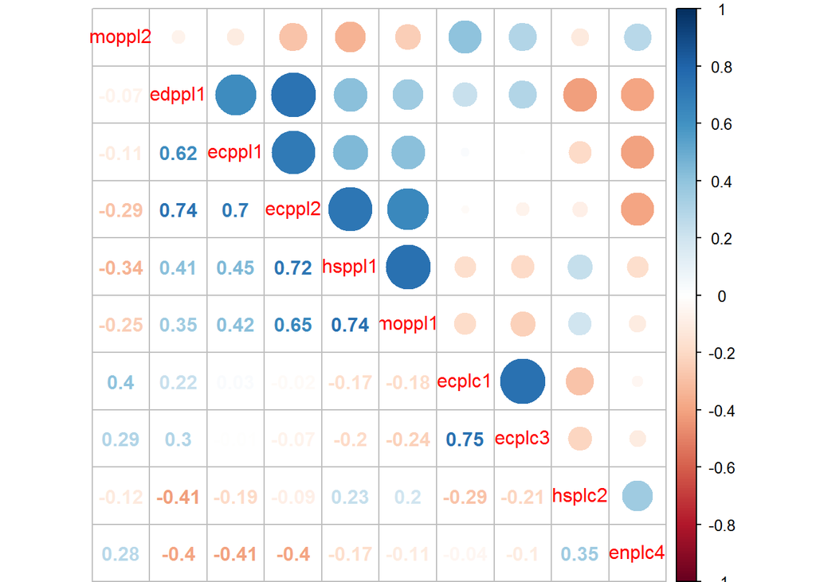

```r
corrplot.mixed (M) #one side is colors and size, one side is the numbers
```

```r
#covariance, just checking to see that it's different
#q<-cov(corrDF, use="complete.obs")
#q
```

#### 2. a) Annotate the snippet of script above.

See above

#### b) Which is any variables should we exclude because of a weak bivariate relationship to moppl2?

edppl1, the college education level of adults, has the weakest relationship with moppl2

#### c) Which if any variables should we exclude because of multicollinearity with other explanatory variables?

There are a few sets of variables which demonstrate collinearity and should be excluded: ecplc3 and ecplc1, job availability and job quality demonstrate collinearity (r=0.75) moppl1 and hsppl1, vehicle availibility and housing cost burden have an r=0.74 hsppl1 and ecppl2 have an r=0.72 (housing cost burden and minimum base income) ecppl2 and ecppl1 have an r=0.7 (minimum income and employment rate)

So, let’s exclude those things! But, I’m not going to remove hsppl1 bc I will use that later. also, I’m removing the other variable it’s correlated with, ecppl2, so that’s ok

```r
ROI_trim <- fread (file.path (datapath, "geo200cn_roi.csv"), select=c("tract", "moppl2", "hsppl1", "moppl1", "hsplc2", "enplc4", "cntyname", "density"))
```

## Regression Analysis

simple model first

```r
#lm, just put y~x, gives you the regression
lm.fit = lm(moppl2~hsppl1, data=ROI_trim)
lm.fit #parameters of lm.fit
```

```
##
## Call:
## lm(formula = moppl2 ~ hsppl1, data = ROI_trim)
##
## Coefficients:
## (Intercept)       hsppl1
##     74.8802      -0.2348
```

```r
summary(lm.fit) #p-values, r2, etc.
```

```
##
## Call:
## lm(formula = moppl2 ~ hsppl1, data = ROI_trim)
##
## Residuals:
##     Min      1Q  Median      3Q     Max
## -38.227  -8.775   1.081   8.878  30.208
##
## Coefficients:
##             Estimate Std. Error t value Pr(>|t|)
## (Intercept)  74.8802     1.3205   56.70   <2e-16 ***
## hsppl1       -0.2348     0.0210  -11.18   <2e-16 ***
## ---
## Signif. codes:  0 '***' 0.001 '**' 0.01 '*' 0.05 '.' 0.1 ' ' 1
##
## Residual standard error: 12.56 on 827 degrees of freedom
##   (12 observations deleted due to missingness)
## Multiple R-squared:  0.1313, Adjusted R-squared:  0.1303
## F-statistic:   125 on 1 and 827 DF,  p-value: < 2.2e-16
```

```r
names(lm.fit) #the information stored in lm.fit
```

```
##  [1] "coefficients"  "residuals"     "effects"       "rank"
##  [5] "fitted.values" "assign"        "qr"            "df.residual"
##  [9] "na.action"     "xlevels"       "call"          "terms"
## [13] "model"
```

```r
coef(lm.fit) #pulls out paramters/coeffecients
```

```
## (Intercept)      hsppl1
##  74.8802343  -0.2347953
```

```r
confint(lm.fit) #confiedence intervals
```

```
##                  2.5 %     97.5 %
## (Intercept) 72.2882011 77.4722674
## hsppl1      -0.2760093 -0.1935814
```

```r
predict (lm.fit, data.frame(hsppl1=(c(0,61,97))), interval="confidence") #confidence intervals at the given values of 0,61,97 for hsppl1
```

```
##        fit      lwr      upr
## 1 74.88023 72.28820 77.47227
## 2 60.55772 59.69870 61.41674
## 3 52.10509 50.33315 53.87703
```

```r
predict (lm.fit, data.frame(hsppl1=(c(0,61,97))), interval="prediction") #predicted values for y at the given values of hsppl1, here the possible values are 0, 61, 97
```

```
##        fit      lwr      upr
## 1 74.88023 50.08786 99.67260
## 2 60.55772 35.88626 85.22918
## 3 52.10509 27.38500 76.82517
```

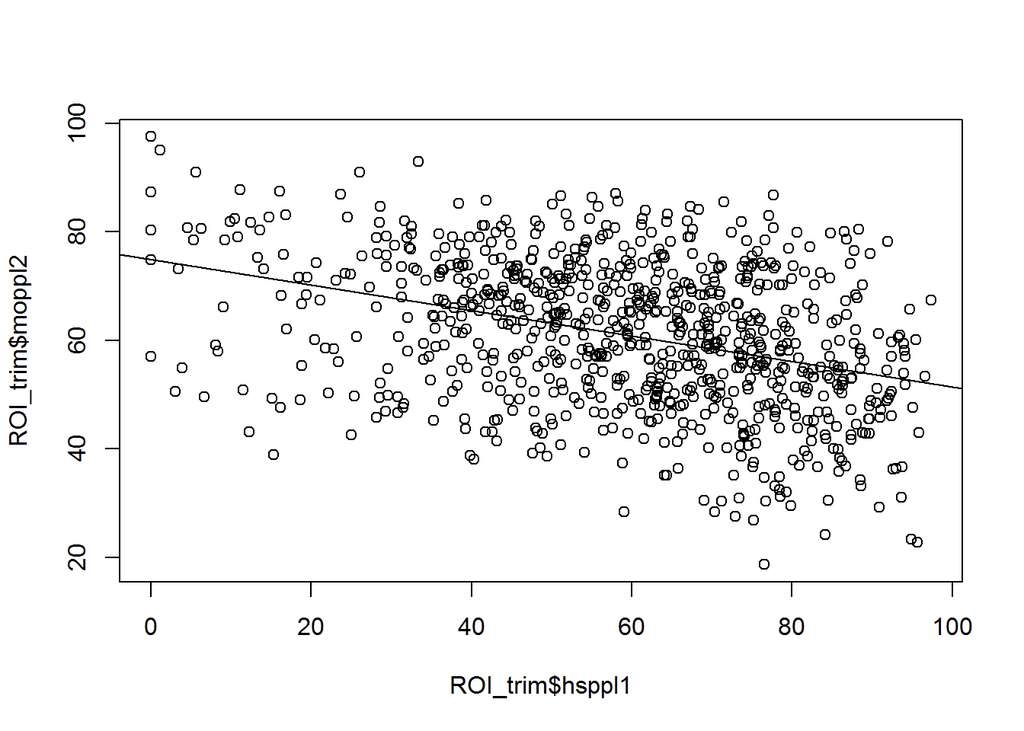

```r
plot(ROI_trim$hsppl1, ROI_trim$moppl2)
abline(lm.fit)
```

#### 3. How would you interpret the results so far? Thinking about the general questions we ask with regression:

#### a) Is there a relationship between the response and explanatory variables?

Yes, there seems to be a relationship between commute time and housing cost burden, based on a high f-statistic.

#### b) What is the relationship and is it positive or negative?

It is a negative linear relationship: Commute time decreases as the percentage of people with a low housing cost burden increases.

#### d) When hspp1 is 61 what is the predicted value of moppl2 and values that deﬁne the 95% conﬁdence and predictor interval?

The 95% prediction interval for values of mopppl2when hspp1 = 61 are 35.88626 (lower) 85.22918 (upper), and the prediction value is 60.5 The 95% confidence value for moppl2 is also as 60.5 (the mean), and the confidence interval is 59.69870, 61.41674.

#### Optional: Choose one of the variables with a weaker bivariate relationship to moppl2, and examine the relationship through another simple linear regression.

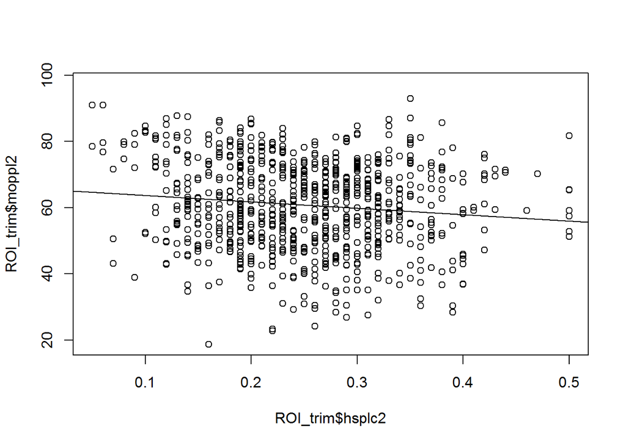

```r
lm.other <-lm(moppl2~hsplc2, data=ROI_trim)
plot(ROI_trim$hsplc2, ROI_trim$moppl2)
abline(lm.other)
```

```r
summary(lm.other)
```

```
##
## Call:
## lm(formula = moppl2 ~ hsplc2, data = ROI_trim)
##
## Residuals:
##     Min      1Q  Median      3Q     Max
## -43.857  -9.827   0.525  10.601  34.092
##
## Coefficients:
##             Estimate Std. Error t value Pr(>|t|)
## (Intercept)   65.610      1.495   43.87  < 2e-16 ***
## hsplc2       -19.205      5.666   -3.39 0.000733 ***
## ---
## Signif. codes:  0 '***' 0.001 '**' 0.01 '*' 0.05 '.' 0.1 ' ' 1
##
## Residual standard error: 13.26 on 821 degrees of freedom
##   (18 observations deleted due to missingness)
## Multiple R-squared:  0.0138, Adjusted R-squared:  0.0126
## F-statistic: 11.49 on 1 and 821 DF,  p-value: 0.0007329
```

The R^2 is even closer to zero, the RSE is 13.26, not much different

# Multiple Linear Regression

## Fit a Least Squares Model

```r
#fit a model with all the variables
lm.fit2 <-lm(moppl2~., data=corrDF) #a period on the right side of the equation means include all the variables
summary (lm.fit2)
```

```
##
## Call:
## lm(formula = moppl2 ~ ., data = corrDF)
##
## Residuals:
##     Min      1Q  Median      3Q     Max
## -37.906  -7.042   0.403   7.645  28.519
##
## Coefficients:
##              Estimate Std. Error t value Pr(>|t|)
## (Intercept) -3.514586  10.428421  -0.337 0.736189
## edppl1       0.084905   0.041013   2.070 0.038751 *
## ecppl1       0.375127   0.093477   4.013 6.55e-05 ***
## ecppl2      -0.187681   0.048488  -3.871 0.000117 ***
## hsppl1      -0.141885   0.033917  -4.183 3.18e-05 ***
## moppl1       0.096556   0.076006   1.270 0.204313
## ecplc1       0.014346   0.001704   8.421  < 2e-16 ***
## ecplc3      -0.058947   0.061356  -0.961 0.336972
## hsplc2      -2.767488   6.440889  -0.430 0.667546
## enplc4       3.132019   0.395839   7.912 8.25e-15 ***
## ---
## Signif. codes:  0 '***' 0.001 '**' 0.01 '*' 0.05 '.' 0.1 ' ' 1
##
## Residual standard error: 11.01 on 813 degrees of freedom
##   (18 observations deleted due to missingness)
## Multiple R-squared:  0.3273, Adjusted R-squared:  0.3199
## F-statistic: 43.96 on 9 and 813 DF,  p-value: < 2.2e-16
```

```r
#fit a model with variables excluded for multicollinarity (only add variables of interest). This means include all variables (the period), except the four that we wrote in with a "-"
lm.fit2b <- lm(moppl2~.-edppl1-ecppl2-moppl1-ecplc3, data=corrDF)
#or, just add in the variables of interest
lm.fit2a <-lm(moppl2~ecppl1+hsppl1+ecplc1+hsplc2+enplc4, data=corrDF)
summary (lm.fit2a)
```

```
##
## Call:
## lm(formula = moppl2 ~ ecppl1 + hsppl1 + ecplc1 + hsplc2 + enplc4,
##     data = corrDF)
##
## Residuals:
##     Min      1Q  Median      3Q     Max
## -36.454  -6.868   0.226   7.981  28.479
##
## Coefficients:
##              Estimate Std. Error t value Pr(>|t|)
## (Intercept)  3.101182   8.670759   0.358   0.7207
## ecppl1       0.269981   0.079349   3.402   0.0007 ***
## hsppl1      -0.182682   0.023172  -7.884 1.02e-14 ***
## ecplc1       0.013375   0.001144  11.696  < 2e-16 ***
## hsplc2      -5.729823   5.628498  -1.018   0.3090
## enplc4       3.492525   0.383054   9.118  < 2e-16 ***
## ---
## Signif. codes:  0 '***' 0.001 '**' 0.01 '*' 0.05 '.' 0.1 ' ' 1
##
## Residual standard error: 11.08 on 817 degrees of freedom
##   (18 observations deleted due to missingness)
## Multiple R-squared:  0.3147, Adjusted R-squared:  0.3105
## F-statistic: 75.05 on 5 and 817 DF,  p-value: < 2.2e-16
```

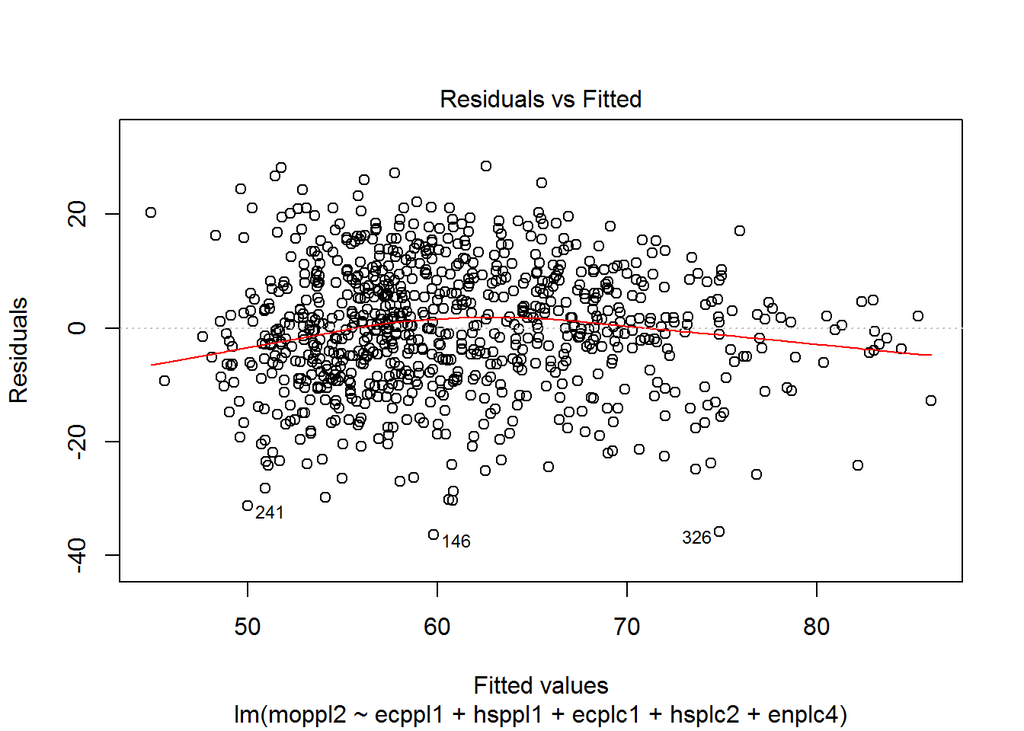

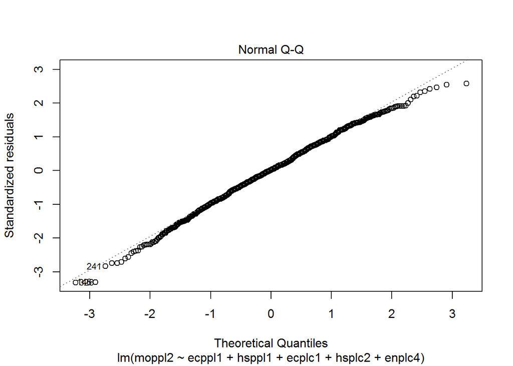

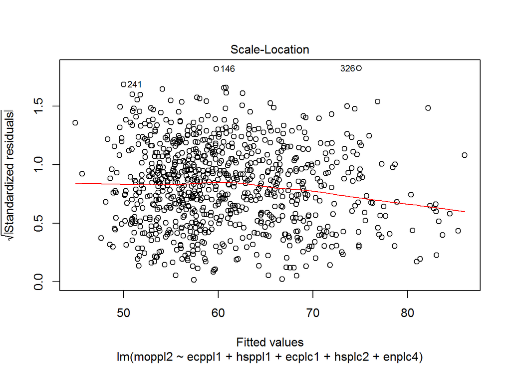

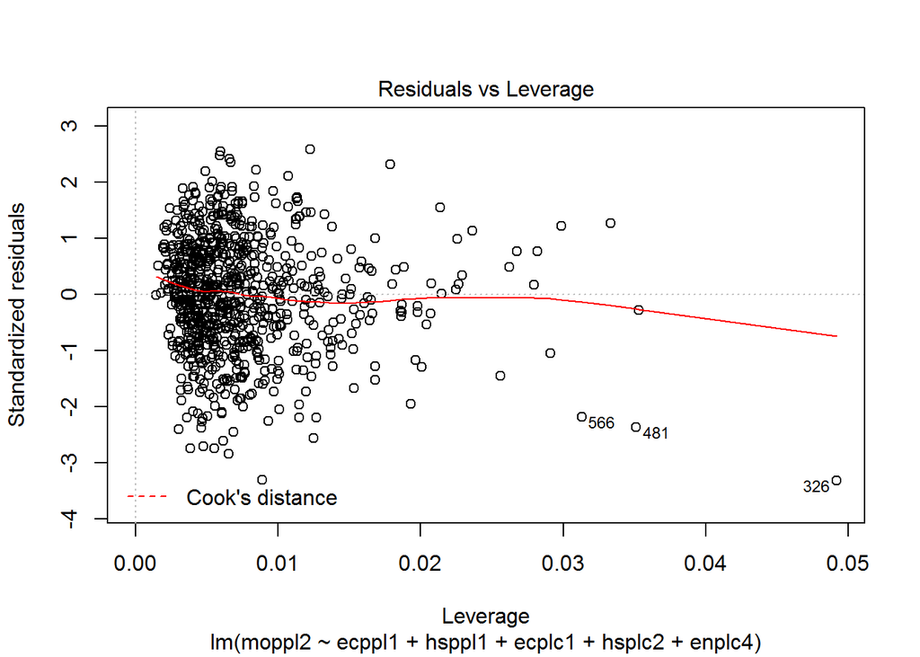

```r
plot(lm.fit2a) #ths is cool bc it shows several plots with all the variables with hitting enter
```

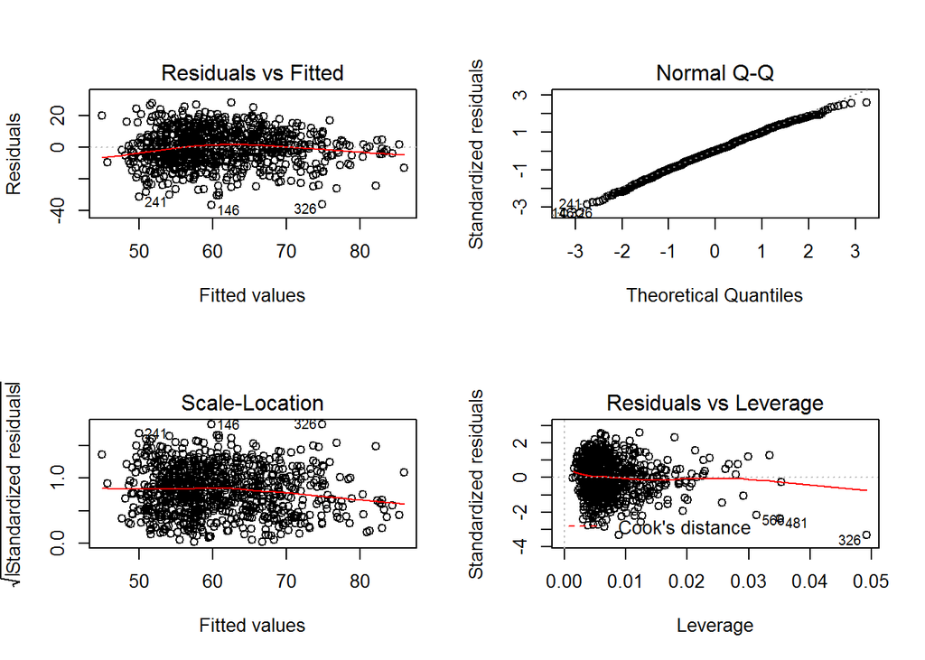

```r
#this shows me all four plots at once
par(mfrow=c(2,2))
plot(lm.fit2a)
```

#### b) Which explanetory variables have a statistically signiﬁcant relationship to the response?

ecppl1, hsppl1, ecplc1, and enplc4 all have p values < 0.05.

#### c) Compare and contrast the results from lm.ﬁt with lm.ﬁt2 or lm.ﬁt2a. How does the overall relationship between the response and explanatory change? How much of the variation in moppl2 is explained by each model. How might you explain these changes. Do the relationships between particular explanatory variables change. [Hint: Take a look at the F-statistics and Rsquares, as well as the coefﬁcients and p-values for individual variables.]

lm.fit (just two variables) has the highest f-statistic, followed by lm.fit2a (the trimmed data set), and lastly lm.fit(the entire data set), meaning that the strongest relationship is seen in lm.fit. This seems to be influenced by how many of the values have a significant p value. All of the plots are relatively similar in terms of RSE- each plot is around 20% (when comparing RSE to the mean.) So, all of these models have a lot of variance that isn’t explained/doesn’t fit with the models themselves. The highest R^2 values are in the multiple linear regression models, and are around .3. Again, this means that the models have a lot of variance. Also, even though the R^2 values are slightly higher, this is expected as they will increase when more variables are added. Interestingly, between lm.fit2 and lim.fit2a, some of the explanatory variables seem to change their relationship with moppl2. ecppl1 has a much smaller pvalue when part of the regression for the entire data set. In contrast, hsplc2 has a smaller pvalue in the reduced data set.

## Best Subset Selection

Automate the covariate selection process. regsubsets performs best subset selection by identifying the best model that contains a given number of predictors, where best is quantiﬁed using RSS

```r
#remove census tracts with missing values for any varirable
corrDF=na.omit (corrDF)
dim(corrDF)
```

```
## [1] 823  10
```

```r
sum(is.na(corrDF)) #0, no nas
```

```
## [1] 0
```

```r
#Subset
#install.packages("leaps")
library (leaps)
#regsubsets is model selection by exhaustive search. uses same syntax as lm. by default is only returns 8 values, nvmax lets you set that higher
regfit.full <- regsubsets(moppl2~., corrDF, nvmax=9)
reg.summary <-(summary (regfit.full))
reg.summary
```

```
## Subset selection object
## Call: regsubsets.formula(moppl2 ~ ., corrDF, nvmax = 9)
## 9 Variables  (and intercept)
##        Forced in Forced out
## edppl1     FALSE      FALSE
## ecppl1     FALSE      FALSE
## ecppl2     FALSE      FALSE
## hsppl1     FALSE      FALSE
## moppl1     FALSE      FALSE
## ecplc1     FALSE      FALSE
## ecplc3     FALSE      FALSE
## hsplc2     FALSE      FALSE
## enplc4     FALSE      FALSE
## 1 subsets of each size up to 9
## Selection Algorithm: exhaustive
##          edppl1 ecppl1 ecppl2 hsppl1 moppl1 ecplc1 ecplc3 hsplc2 enplc4
## 1  ( 1 ) " "    " "    " "    " "    " "    "*"    " "    " "    " "
## 2  ( 1 ) " "    " "    " "    " "    " "    "*"    " "    " "    "*"
## 3  ( 1 ) " "    " "    " "    "*"    " "    "*"    " "    " "    "*"
## 4  ( 1 ) " "    "*"    " "    "*"    " "    "*"    " "    " "    "*"
## 5  ( 1 ) " "    "*"    "*"    "*"    " "    "*"    " "    " "    "*"
## 6  ( 1 ) "*"    "*"    "*"    "*"    " "    "*"    " "    " "    "*"
## 7  ( 1 ) "*"    "*"    "*"    "*"    "*"    "*"    " "    " "    "*"
## 8  ( 1 ) "*"    "*"    "*"    "*"    "*"    "*"    "*"    " "    "*"
## 9  ( 1 ) "*"    "*"    "*"    "*"    "*"    "*"    "*"    "*"    "*"
```

```r
names (reg.summary)
```

```
## [1] "which"  "rsq"    "rss"    "adjr2"  "cp"     "bic"    "outmat" "obj"
```

#### Plot Subsections: Plotting RSS, adjusted R2, Cp, and BIC togther, can help us decide what on the best overall model. (Remeber R2 will simply increase as more variables are added to the model.) The functions which.max() or which.min(), as appropriate will identify the best model using any particular measurement. Remember for adjusted R2 you are looking for the max and for Cp and BIC you are looking for the min.

```r
par(mfrow=c(2,2)) #sets the panel to see multiple plots at a time
plot (reg.summary$rss, xlab="Number of Variables", ylab="RSS", type="l") #show relationship between RSS and number of variables- which number of variables is it best to use to use for minimal RSS. RSS gets smaller as more variables added (as is always the case)

#Rsq
plot (reg.summary$adjr2, xlab="Number of Variables", ylab="Adjusted RSq", type="l")  #how many variables are needed for adj R^2 to reach its maximum. Looks like it hits that around 5.

which.max(reg.summary$adjr2) #I'm wrong, this tells us the max r^2 happens with 8 variables
```

```
## [1] 8
```

```r
points(8, reg.summary$adjr2[8], col="red", cex=2, pch=20) #adds a point at the max R^2

#Cp
plot (reg.summary$cp, xlab="Number of Variables", ylab="Cp", type="l") #plots Cp against variables.  Cp assesses fit of the model, and a small Cp means its relatively precise
which.min(reg.summary$cp) #6 variables is when we get a small Cp
```

```
## [1] 6
```

```r
points(6, reg.summary$cp [6],col="red",cex=2,pch=20) #added a point to the Cp
#BIC
which.min(reg.summary$bic) #bic is Bayesian Information Criterion, here the value is 5.
```

```
## [1] 5
```

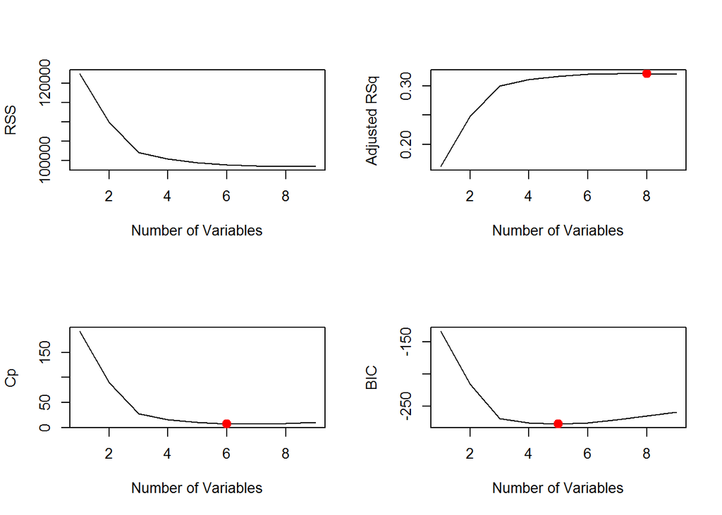

```r
plot (reg.summary$bic, xlab="Number of Variables", ylab="BIC", type='l')  #plots the BIC
points(5, reg.summary$bic [5],col="red", cex=2, pch=20) #adds a point for the best BIC value
```

#### 5. Annotate this snippet of code, and compare and contrast the results. [Hint: compare these different measures and think about why they return different best models]

Annotated above. Cp adds a penalty to the RSS for each additional variable. The lower the test error (the RSS error), the smaller the value that Cp takes on. Cp=AIC in this case, and uses maximum likelihood to fit. The BIC value is the smallest. This is becauseBIC also takes a small value for low test error models, and puts a penalty on for additional variables. But, BIC uses a heavier penalty, the value returned is usually smaller than Cp. The R^2 is large because R^2 is the opposite- a large value indicates a small test error. A large adjR^2 has only valuable variables and no noise variables.

Plot all the subsets

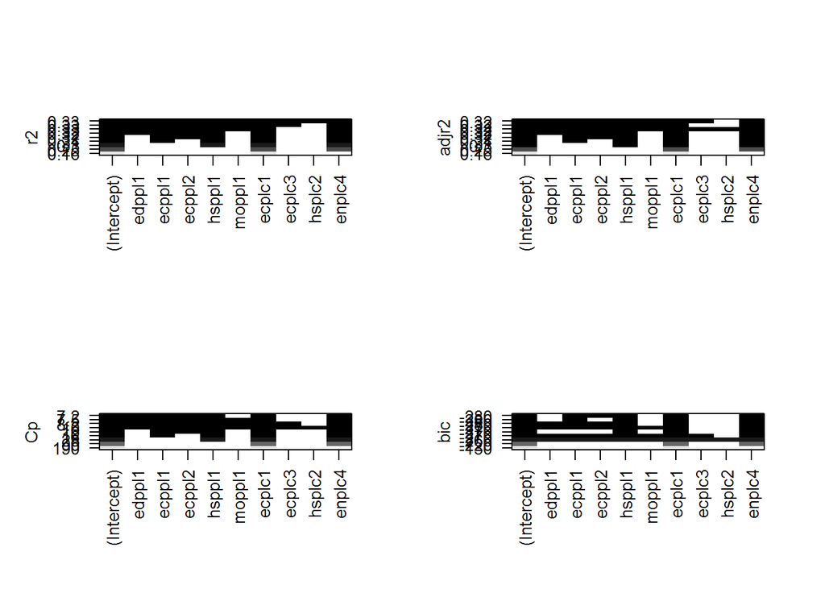

```r
par(mfrow=c(2,2))
plot (regfit.full, scale="r2")
plot (regfit.full, scale="adjr2")
plot (regfit.full, scale="Cp")
plot (regfit.full, scale="bic")
```

```r
coef(regfit.full, 5)
```

```
## (Intercept)      ecppl1      ecppl2      hsppl1      ecplc1      enplc4
## -4.13971323  0.42687859 -0.11016995 -0.13724329  0.01393457  3.11634010
```

```r
#best model coefficients:
#(Intercept)      ecppl1      ecppl2      hsppl1
#-4.13971323  0.42687859 -0.11016995 -0.13724329
#     ecplc1      enplc4
# 0.01393457  3.11634010
```

You can use reg.summary () to conduct forward or backwards subsection selection.

```r
regfit.fwd <-regsubsets(moppl2~., corrDF, nvmax=9, method="forward")
sumregfwd<-summary (regfit.fwd)
regfit.bwd = regsubsets(moppl2~., corrDF, nvmax=9, method="backward")
sumregbwd<-summary (regfit.bwd)
```

#### 6. repeat the steps above to compare and contrast the best models using forward and backwards subset selection with each measure (RSS, adjusted R2, Cp, and BIC). Are the selected explanatory variables largely the same? Do predicted covarients differ? How do these models compare the lm.ﬁt2 above?

```r
#Forward
par(mfrow=c(2,2))
plot (sumregfwd$rss, xlab="Number of Variables", ylab="RSS", type="l")

#Rsq
plot (sumregfwd$adjr2, xlab="Number of Variables", ylab="Adjusted RSq", type="l")
which.max(sumregfwd$adjr2) #8
```

```
## [1] 8
```

```r
#Cp
plot (sumregfwd$cp, xlab="Number of Variables", ylab="Cp", type="l")
which.min(sumregfwd$cp) #6
```

```
## [1] 6
```

```r
#BIC
which.min(sumregfwd$bic) #5
```

```
## [1] 5
```

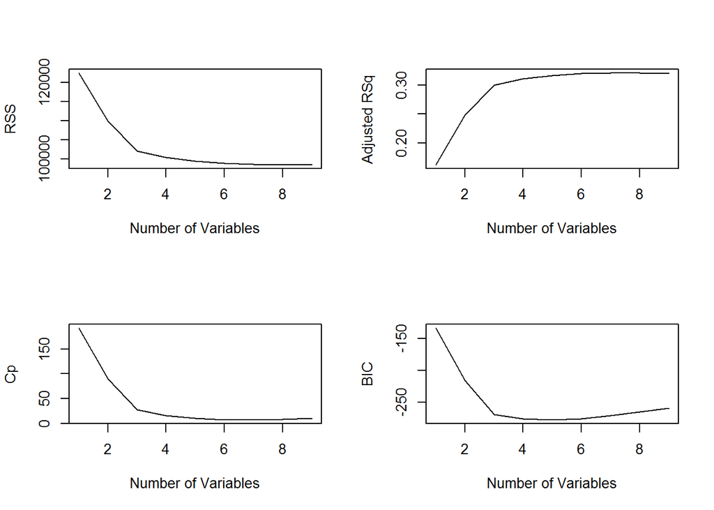

```r
plot (reg.summary$bic, xlab="Number of Variables", ylab="BIC", type='l')
```

```r
coef(regfit.fwd,5)
```

```
## (Intercept)      ecppl1      ecppl2      hsppl1      ecplc1      enplc4
## -4.13971323  0.42687859 -0.11016995 -0.13724329  0.01393457  3.11634010
```

```r
#(Intercept)      ecppl1      ecppl2      hsppl1      ecplc1      enplc4
#-4.13971323  0.42687859 -0.11016995 -0.13724329  0.01393457  3.11634010

#Backward
which.max(sumregbwd$adjr2) #8
```

```
## [1] 8
```

```r
which.min(sumregbwd$cp) #6
```

```
## [1] 6
```

```r
which.min(sumregbwd$bic) #5
```

```
## [1] 5
```

```r
coef(regfit.bwd,5)
```

```
## (Intercept)      ecppl1      ecppl2      hsppl1      ecplc1      enplc4
## -4.13971323  0.42687859 -0.11016995 -0.13724329  0.01393457  3.11634010
```

```r
#(Intercept)      ecppl1      ecppl2      hsppl1      ecplc1      enplc4
#-4.13971323  0.42687859 -0.11016995 -0.13724329  0.01393457  3.11634010
```

All of the subsetting returns the same results. The models all want the same number of variables, and the coefficients are the same, regardless of the subsetting. However, the subsetting does return different values than lm.fit2 (with all variables.) The intercept is slightly lower in the subsetting (subsetting=-4.1, lm.fit2=-3.5.) There is slight variation in a couple of the variables-ecppl1 and ecppl2 show the most difference between lm.fit2 and the subset of data. The other variables have almost the same value.